# Market basket Analysis

Soheil Garfami

2024-08-19

# **Introduction**

Hi! In this kernel we are going to use the **Apriori algorithm** to perform a **Market Basket Analysis**. It’s a technique used by large retailers to uncover associations between items. It works by looking for combinations of items that occur together frequently in transactions, providing information to understand the purchase behavior. The outcome of this type of technique is, in simple terms, a set of **rules** that can be understood as **“if this, then that”**.

### Key Objectives

*Market Basket Analysis & Association Rules*

In this section we use association rules and the a priori algorithm to identify purchase patterns and answer the following questions:

- Do customers purchase items together frequently and which products are most often purchased together ?
- Can we use this information to recommend other products based on a customer’s cart ?

### Importing the data

First, let’s import the required libraries.

```r
library(arules)
library(arulesViz)
library(tidyverse)
library(ggplot2)
library(DataExplorer)
library(gridExtra)
```

let’s see the data set that we built by joining all datasets

```r
JOINED <- read.csv("data/JOINED.csv")
head(JOINED)
```

```
##   order_id product_id add_to_cart_order reordered user_id eval_set order_number
## 1        1      49302                 1         1  112108    train            4
## 2        1      11109                 2         1  112108    train            4
## 3        1      10246                 3         0  112108    train            4
## 4        1      49683                 4         0  112108    train            4
## 5        1      43633                 5         1  112108    train            4
## 6        1      13176                 6         0  112108    train            4
##   order_dow order_hour_of_day days_since_prior_order
## 1         4                10                      9
## 2         4                10                      9
## 3         4                10                      9
## 4         4                10                      9
## 5         4                10                      9
## 6         4                10                      9
##                                    product_name aisle_id department_id
## 1                              Bulgarian Yogurt      120            16
## 2 Organic 4% Milk Fat Whole Milk Cottage Cheese      108            16
## 3                         Organic Celery Hearts       83             4
## 4                                Cucumber Kirby       83             4
## 5          Lightly Smoked Sardines in Olive Oil       95            15
## 6                        Bag of Organic Bananas       24             4
##                  aisle   department
## 1               yogurt   dairy eggs
## 2 other creams cheeses   dairy eggs
## 3     fresh vegetables      produce
## 4     fresh vegetables      produce
## 5  canned meat seafood canned goods
## 6         fresh fruits      produce
```

To apply the `Apriori` algorithm in `market basket analysis`, we need to have a **transactions** dataset. We can import the dataset in the required transaction format using the `arules` library. For this, we’ll need the columns for transaction ID and product name.

```r
JOINED[1,c(1,11)]
```

```
##   order_id     product_name
## 1        1 Bulgarian Yogurt
```

As you can see, the `transactionId` and `productName` columns are in positions 1 and 11, respectively.

let’s imprort the dataset as transactions. (columns 1 and 11)

```r
rm(JOINED)
trans <- read.transactions("data/JOINED.csv" , format = "single" , sep = "," , cols = c(1 ,11))
trans
```

```
## transactions in sparse format with
##  131210 transactions (rows) and
##  39124 items (columns)
```

let’s see the first transaction

```r
inspect(trans[1])
```

```
##     items                                            transactionID
## [1] {Bag of Organic Bananas,
##      Bulgarian Yogurt,
##      Cucumber Kirby,
##      Lightly Smoked Sardines in Olive Oil,
##      Organic 4% Milk Fat Whole Milk Cottage Cheese,
##      Organic Celery Hearts,
##      Organic Hass Avocado,
##      Organic Whole String Cheese}                                1
```

With the `itemFrequencyPlot`, we can again visualize a graph of the most popular products.

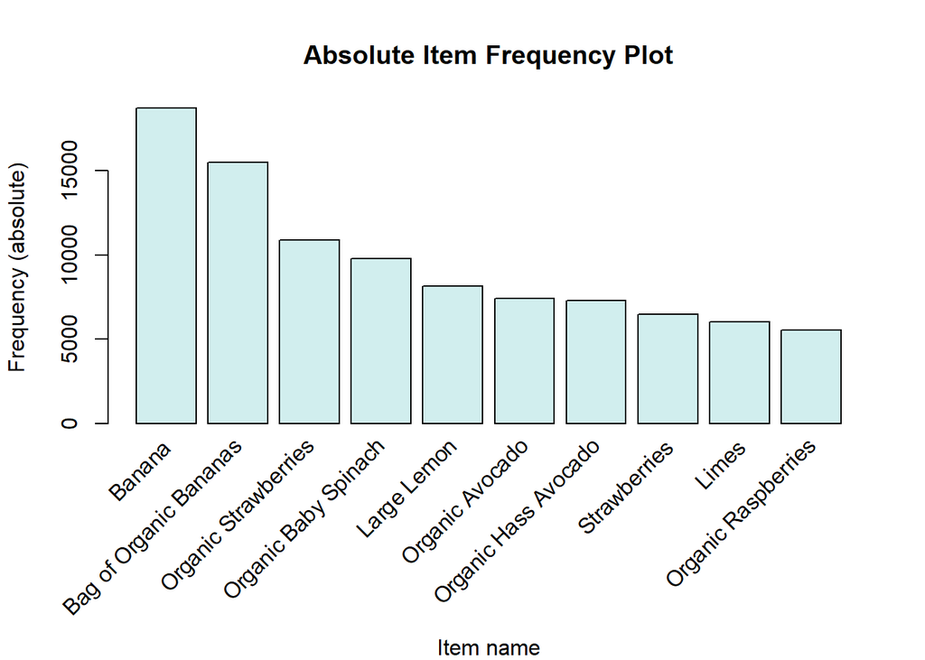

```r
itemFrequencyPlot(trans ,topN=10 , type="absolute" ,col="lightcyan2",xlab="Item name",
                  ylab="Frequency (absolute)", main="Absolute Item Frequency Plot")
```

# **Selecting the Optimal Values for Parameters**

The Apriori algorithm generates association rules for a given dataset. An association rule suggests that if item A occurs, then item B is likely to occur with a certain probability.

To extract these rules using the Apriori algorithm, there are three key arguments that are crucial for obtaining the best rules:

- **Support**: Indicates how frequently the itemset appears in the dataset.
- **Confidence**: Reflects how often the rule has been found to be true.
- **Lift**: Represents the ratio of the observed support to that expected if X and Y were independent. If the lift is greater than 1, it indicates the strength of the relationship between the two items, showing how dependent they are on each other.

Now, we will use the `gridExtra` package to build different rules with varying parameters and plot them to determine which set of rules is the most suitable.

```r
# Support and confidence values
supportLevels <- c( 0.05, 0.01, 0.005 , 0.001)
confidenceLevels <- c(  0.7, 0.6, 0.5, 0.4, 0.3, 0.2, 0.1 , 0.05 , 0.1)

# Empty integers
rules_sup5 <- integer(length=9)
rules_sup1 <- integer(length=9)
rules_sup0.5 <- integer(length=9)
rules_sup0.1 <- integer(length=9)
```

```r
# Apriori algorithm with a support level of 5%
for (i in 1:length(confidenceLevels)) {

  rules_sup5[i] <- length(apriori(trans, parameter=list(sup=supportLevels[1],
                                                         conf=confidenceLevels[i],target="rules"),
                                control = list(verbose = FALSE)))
}

# Apriori algorithm with a support level of 1%
for (i in 1:length(confidenceLevels)){

  rules_sup1[i] <- length(apriori(trans, parameter=list(sup=supportLevels[2],
                                                        conf=confidenceLevels[i], target="rules"),
                                control = list(verbose = FALSE)))
}

# Apriori algorithm with a support level of 0.5%
for (i in 1:length(confidenceLevels)){

  rules_sup0.5[i] <- length(apriori(trans, parameter=list(sup=supportLevels[3],
                                                        conf=confidenceLevels[i],target="rules"),
                                control = list(verbose = FALSE)))
}

# Apriori algorithm with a support level of 0.1%
for (i in 1:length(confidenceLevels)){

  rules_sup0.1[i] <- length(apriori(trans, parameter=list(sup=supportLevels[4],
                                                          conf=confidenceLevels[i], target="rules"),
                                control = list(verbose = FALSE)))
}
```

```r
rules_sup5
```

```
## [1] 0 0 0 0 0 0 2 7 2
```

```r
rules_sup1
```

```
## [1]  0  0  0  0  3 12 33 39 33
```

```r
rules_sup0.5
```

```
## [1]   0   0   0   1  13  55 141 203 141
```

```r
rules_sup0.1
```

```
## [1]    0    0   11   89  347 1172 2519 3992 2519
```

*Now, let’s plot the number of rules generated for each confidence level at each support level.*

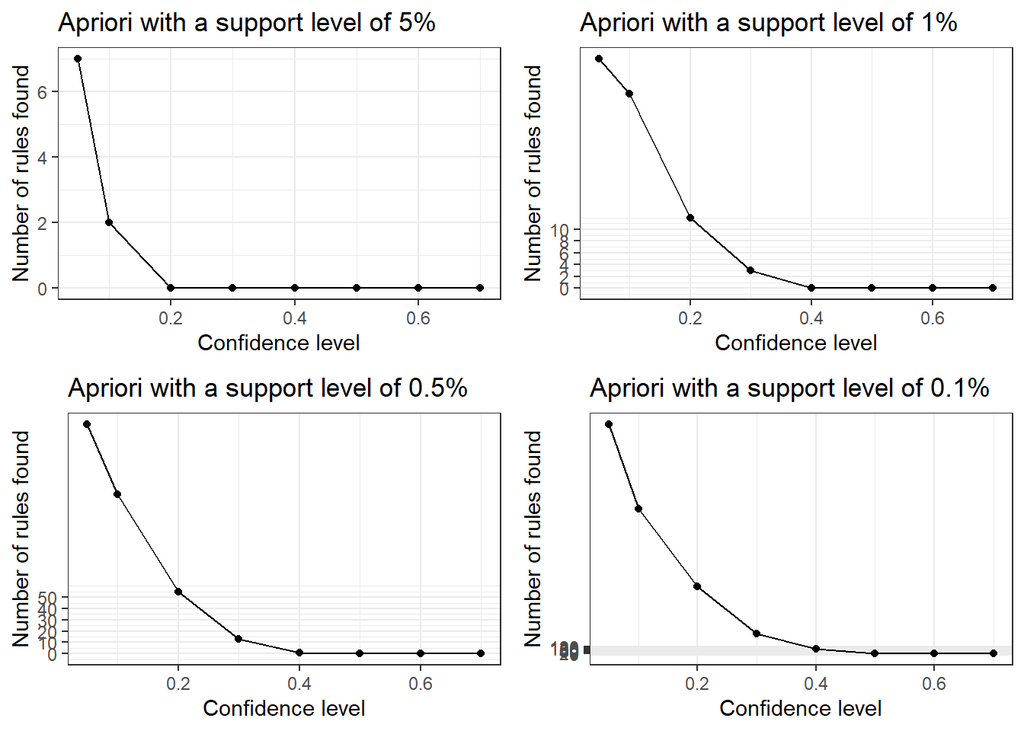

```r
# Number of rules found with a support level of 5%
plot1 <- qplot(confidenceLevels, rules_sup5, geom=c("point", "line"),
               xlab="Confidence level", ylab="Number of rules found",
               main="Apriori with a support level of 5%") +
  theme_bw()

# Number of rules found with a support level of 1%
plot2 <- qplot(confidenceLevels, rules_sup1, geom=c("point", "line"),
               xlab="Confidence level", ylab="Number of rules found",
               main="Apriori with a support level of 1%") +
  scale_y_continuous(breaks=seq(0, 10, 2)) +
  theme_bw()

# Number of rules found with a support level of 0.5%
plot3 <- qplot(confidenceLevels, rules_sup0.5, geom=c("point", "line"),
               xlab="Confidence level", ylab="Number of rules found",
               main="Apriori with a support level of 0.5%") +
  scale_y_continuous(breaks=seq(0, 50, 10)) +
  theme_bw()

# Number of rules found with a support level of 0.1%
plot4 <- qplot(confidenceLevels, rules_sup0.1, geom=c("point", "line"),
               xlab="Confidence level", ylab="Number of rules found",
               main="Apriori with a support level of 0.1%") +
  scale_y_continuous(breaks=seq(0, 130, 20)) +
  theme_bw()

# Subplot
grid.arrange(plot1, plot2, plot3, plot4, ncol=2)
```

*Let’s plot them all together so we can compare them.*

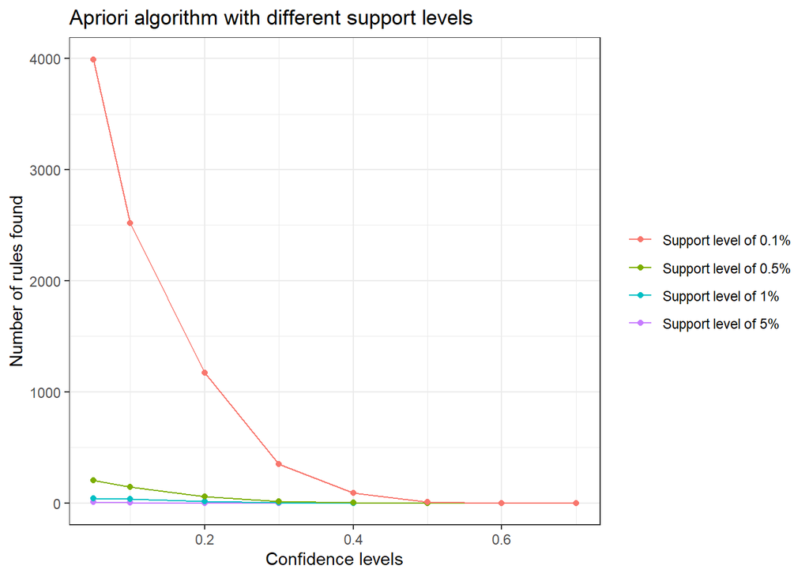

```r
num_rules <- data.frame(rules_sup5, rules_sup1, rules_sup0.5, rules_sup0.1, confidenceLevels)

# Number of rules found with a support level of 10%, 5%, 1% and 0.5%
ggplot(data=num_rules, aes(x=confidenceLevels)) +

  # Plot line and points (support level of 10%)
  geom_line(aes(y=rules_sup5, colour="Support level of 5%")) +
  geom_point(aes(y=rules_sup5, colour="Support level of 5%")) +

  # Plot line and points (support level of 5%)
  geom_line(aes(y=rules_sup1, colour="Support level of 1%")) +
  geom_point(aes(y=rules_sup1, colour="Support level of 1%")) +

  # Plot line and points (support level of 1%)
  geom_line(aes(y=rules_sup0.5, colour="Support level of 0.5%")) +
  geom_point(aes(y=rules_sup0.5, colour="Support level of 0.5%")) +

  # Plot line and points (support level of 0.5%)
  geom_line(aes(y=rules_sup0.1, colour="Support level of 0.1%")) +
  geom_point(aes(y=rules_sup0.1, colour="Support level of 0.1%")) +

  # Labs and theme
  labs(x="Confidence levels", y="Number of rules found",
       title="Apriori algorithm with different support levels") +
  theme_bw() +
  theme(legend.title=element_blank())
```

# **Analysis & Association Rules**

```r
rules <- apriori(trans, parameter=list(sup=supportLevels[4],
                                                   conf=confidenceLevels[3], target="rules"),
                                control = list(verbose = FALSE))
rules
```

```
## set of 11 rules
```

```r
inspect(head(rules))
```

```
##     lhs                                  rhs                          support confidence    coverage     lift count
## [1] {Organic Broccoli,
##      Organic Hass Avocado}            => {Bag of Organic Bananas} 0.001196555  0.5048232 0.002370246 4.278931   157
## [2] {Organic Hass Avocado,
##      Organic Unsweetened Almond Milk} => {Bag of Organic Bananas} 0.001249905  0.5141066 0.002431217 4.357618   164
## [3] {Organic Navel Orange,
##      Organic Raspberries}             => {Bag of Organic Bananas} 0.001150827  0.5412186 0.002126362 4.587422   151
## [4] {Organic Hass Avocado,
##      Organic Navel Orange}            => {Bag of Organic Bananas} 0.001493789  0.5283019 0.002827528 4.477939   196
## [5] {Organic Hass Avocado,
##      Organic Kiwi}                    => {Bag of Organic Bananas} 0.001448060  0.5459770 0.002652237 4.627755   190
## [6] {Organic D'Anjou Pears,
##      Organic Hass Avocado}            => {Bag of Organic Bananas} 0.001387089  0.5170455 0.002682722 4.382528   182
```

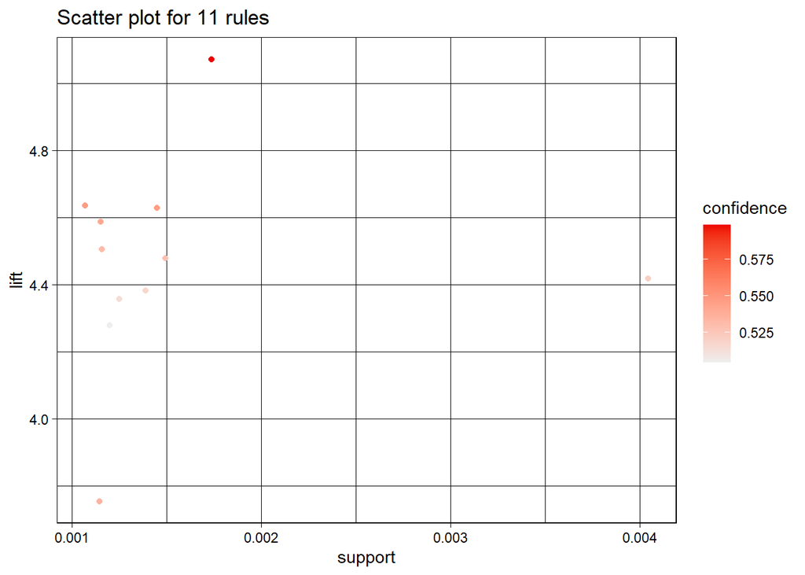

```r
plot(rules, measure=c("support", "lift"), shading="confidence")
```

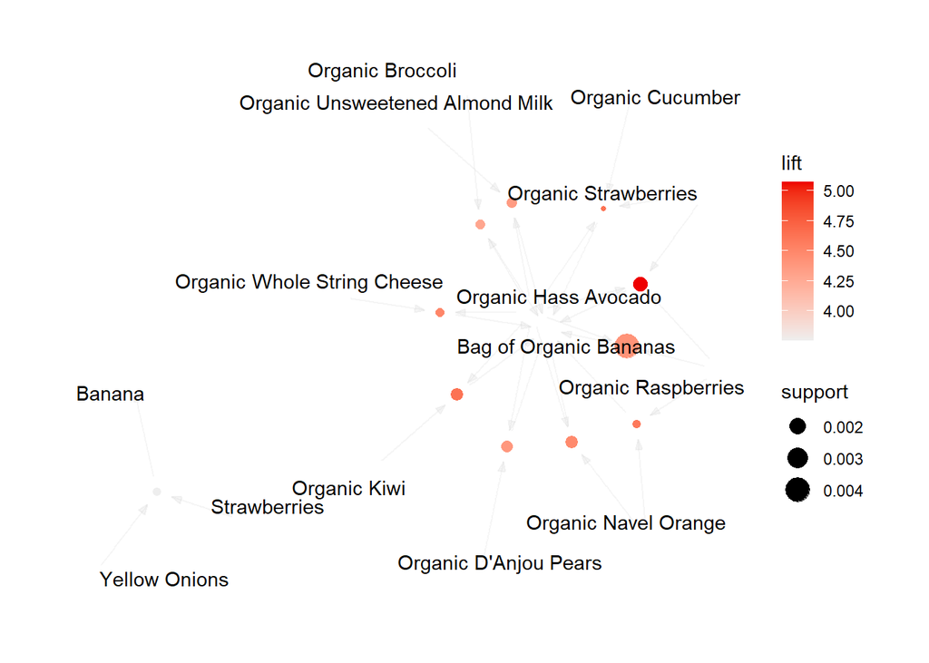

```r
plot(rules, method="graph")
```

*Now, I want to explore 4-product associations to determine if purchasing products A, B, and C increases the likelihood of purchasing product D.*

```r
rules <- apriori(trans, parameter=list(sup=supportLevels[4],
                                                   conf=confidenceLevels[4],minlen =4 , maxlen=4, target="rules"),
                                control = list(verbose = FALSE))
rules
```

```
## set of 6 rules
```

```r
inspect(head(rules))
```

```
##     lhs                          rhs                          support confidence    coverage     lift count
## [1] {Organic Cucumber,
##      Organic Hass Avocado,
##      Organic Strawberries}    => {Bag of Organic Bananas} 0.001066992  0.5468750 0.001951071 4.635366   140
## [2] {Organic Hass Avocado,
##      Organic Raspberries,
##      Organic Strawberries}    => {Bag of Organic Bananas} 0.001737672  0.5984252 0.002903742 5.072311   228
## [3] {Bag of Organic Bananas,
##      Organic Hass Avocado,
##      Organic Raspberries}     => {Organic Strawberries}   0.001737672  0.4293785 0.004046948 5.171540   228
## [4] {Banana,
##      Limes,
##      Organic Avocado}         => {Large Lemon}            0.001112720  0.4147727 0.002682722 6.689899   146
## [5] {Large Lemon,
##      Organic Avocado,
##      Organic Baby Spinach}    => {Banana}                 0.001021264  0.4011976 0.002545538 2.811126   134
## [6] {Organic Baby Spinach,
##      Organic Hass Avocado,
##      Organic Strawberries}    => {Bag of Organic Bananas} 0.001242283  0.4939394 0.002515052 4.186679   163
```

# **Conclusion**

- Using association rules we have identfied items that customers purchase together frequently and which products are most often purchased together
- In addition, we have an apriori model that we can use to recommend instcart customer products based their existing cart !